# Data Handling: Import, Cleaning and Visualisation

Lecture 6, part 2:  
Non-rectangular data

Dr. Aurélien Sallin

2024-11-14

# Welcome back!

## Updates

- **Exam for exchange students** 🎁: 19.12.2024 at 16:15 in room 01-207.
- The reading list has been updated (R4DS Second edition)
- Walk-ins for the digital exam:
  - **04.12.2024** (10:30-14:30, Wintergarten 11:111 Square)
  - **17.12.2024** (10:30-14:30, Wintergarten 11:1111 Square)
- The *mock exam* is online 💣

## Recap

#### Rectangular data

- Import data from text files, csv, tsv, etc.
- Tibbles, data frames in R

#### Non-rectangular data

- Hierarchical data (xml, html, json)
- Unstructured text data and images/pictures data

#### Non-rectangular data for economic research

- csv, json, API for economic research
- Link to guest lecture: [here](https://minnaheim.github.io/dh_guest_lecture/lecture.html#/reality-apis)

# Today (first period)

## Goals

- Understand non-rectangular data: xml, json, and html
- Be familiar with the way we parse these data into R
- Scrape a webpage following its html structure

# Non-rectangular data structures

## Non-rectangular data

- Hierarchical data (xml, html, json)
  - XML and JSON (useful for complex/high-dimensional data sets).
  - HTML (a markup language to define the structure and layout of webpages).
- Unstructured text data
- Images/Pictures data

## A hierarchical data set

```
father mother  name     age  gender
               John      33  male
               Julia     32  female
John   Julia   Jack       6  male
John   Julia   Jill       4  female
John   Julia   John jnr   2  male
               David     45  male
               Debbie    42  female
David  Debbie  Donald    16  male
David  Debbie  Dianne    12  female
```

# XML

## XML = eXtensible Markup Language

#### Recap (from last time):

- **Human-readable**: XML files can be easily read and understood without needing special tools.
- **Self-descriptive**: XML tags describe the data they enclose.
- **Hierarchical structure**: Data is organized in a tree-like structure, making it easy to represent complex relationships.

**See a XML representation of a Word document on [the Wikipedia page on Microsoft Office XML format](https://en.wikipedia.org/wiki/Microsoft_Office_XML_formats)**

```xml
<?xml version="1.0" encoding="utf-8" standalone="yes"?>
<?mso-application progid="Word.Document"?>
<w:wordDocument
   xmlns:w="http://schemas.microsoft.com/office/word/2003/wordml"
   xmlns:wx="http://schemas.microsoft.com/office/word/2003/auxHint"
   xmlns:o="urn:schemas-microsoft-com:office:office"
   w:macrosPresent="no"
   w:embeddedObjPresent="no"
   w:ocxPresent="no"
   xml:space="preserve">
  <o:DocumentProperties>
    <o:Title>This is the title</o:Title>
    <o:Author>Darl McBride</o:Author>
    <o:LastAuthor>Bill Gates</o:LastAuthor>
    <o:Revision>1</o:Revision>
    <o:TotalTime>0</o:TotalTime>
    <o:Created>2007-03-15T23:05:00Z</o:Created>
    <o:LastSaved>2007-03-15T23:05:00Z</o:LastSaved>
    <o:Pages>1</o:Pages>
    <o:Words>6</o:Words>
    <o:Characters>40</o:Characters>
    <o:Company>SCO Group, Inc.</o:Company>
    <o:Lines>1</o:Lines>
    <o:Paragraphs>1</o:Paragraphs>
    <o:CharactersWithSpaces>45</o:CharactersWithSpaces>
    <o:Version>11.6359</o:Version>
  </o:DocumentProperties>
  <w:fonts>
    <w:defaultFonts
       w:ascii="Times New Roman"
       w:fareast="Times New Roman"
       w:h-ansi="Times New Roman"
       w:cs="Times New Roman" />
  </w:fonts>

  <w:styles>
    <w:versionOfBuiltInStylenames w:val="4" />
    <w:latentStyles w:defLockedState="off" w:latentStyleCount="156" />
    <w:style w:type="paragraph" w:default="on" w:styleId="Normal">
      <w:name w:val="Normal" />
      <w:rPr>
        <wx:font wx:val="Times New Roman" />
        <w:sz w:val="24" />
        <w:sz-cs w:val="24" />
        <w:lang w:val="EN-US" w:fareast="EN-US" w:bidi="AR-SA" />
      </w:rPr>
    </w:style>
    <w:style w:type="paragraph" w:styleId="Heading1">
      <w:name w:val="heading 1" />
      <wx:uiName wx:val="Heading 1" />
      <w:basedOn w:val="Normal" />
      <w:next w:val="Normal" />
      <w:rsid w:val="00D93B94" />
      <w:pPr>
        <w:pStyle w:val="Heading1" />
        <w:keepNext />
        <w:spacing w:before="240" w:after="60" />
        <w:outlineLvl w:val="0" />
      </w:pPr>
      <w:rPr>
        <w:rFonts w:ascii="Arial" w:h-ansi="Arial" w:cs="Arial" />
        <wx:font wx:val="Arial" />
        <w:b />
        <w:b-cs />
        <w:kern w:val="32" />
        <w:sz w:val="32" />
        <w:sz-cs w:val="32" />
      </w:rPr>
    </w:style>
    <w:style w:type="character" w:default="on" w:styleId="DefaultParagraphFont">
      <w:name w:val="Default Paragraph Font" />
      <w:semiHidden />
    </w:style>
    <w:style w:type="table" w:default="on" w:styleId="TableNormal">
      <w:name w:val="Normal Table" />
      <wx:uiName wx:val="Table Normal" />
      <w:semiHidden />
      <w:rPr>
        <wx:font wx:val="Times New Roman" />
      </w:rPr>
      <w:tblPr>
        <w:tblInd w:w="0" w:type="dxa" />
        <w:tblCellMar>
          <w:top w:w="0" w:type="dxa" />
          <w:left w:w="108" w:type="dxa" />
          <w:bottom w:w="0" w:type="dxa" />
          <w:right w:w="108" w:type="dxa" />
        </w:tblCellMar>
      </w:tblPr>
    </w:style>
    <w:style w:type="list" w:default="on" w:styleId="NoList">
      <w:name w:val="No List" />
      <w:semiHidden />
    </w:style>
  </w:styles>
  <w:docPr>
    <w:view w:val="print" />
    <w:zoom w:percent="100" />
    <w:doNotEmbedSystemFonts />
    <w:proofState w:spelling="clean" w:grammar="clean" />
    <w:attachedTemplate w:val="" />
    <w:defaultTabStop w:val="720" />
    <w:punctuationKerning />
    <w:characterSpacingControl w:val="DontCompress" />
    <w:optimizeForBrowser />
    <w:validateAgainstSchema />
    <w:saveInvalidXML w:val="off" />
    <w:ignoreMixedContent w:val="off" />
    <w:alwaysShowPlaceholderText w:val="off" />
    <w:compat>
      <w:breakWrappedTables />
      <w:snapToGridInCell />
      <w:wrapTextWithPunct />
      <w:useAsianBreakRules />
      <w:dontGrowAutofit />
    </w:compat>
  </w:docPr>
  <w:body>
    <wx:sect>
      <w:p>
        <w:r>
          <w:t>This is the first paragraph</w:t>
        </w:r>
      </w:p>
      <wx:sub-section>
        <w:p>
          <w:pPr>
            <w:pStyle w:val="Heading1" />
          </w:pPr>
          <w:r>
            <w:t>This is a heading</w:t>
          </w:r>
        </w:p>
        <w:sectPr>
          <w:pgSz w:w="12240" w:h="15840" />
          <w:pgMar w:top="1440"
           w:right="1800"
           w:bottom="1440"
           w:left="1800"
           w:header="720"
           w:footer="720"
           w:gutter="0" />
          <w:cols w:space="720" />
          <w:docGrid w:line-pitch="360" />
        </w:sectPr>
      </wx:sub-section>
    </wx:sect>
  </w:body>
</w:wordDocument>
```

## XML markup is structured by special characters and tags

- A predefined set of special characters (here primarily `<`, `>`, and `/` ) give the data structure.

```xml
<?xml version="1.0" encoding="UTF-8"?>
<data>
  <row>
    <unique_id>216498</unique_id>
    <indicator_id>386</indicator_id>
    <name>Ozone (O3)</name>
    <measure>Mean</measure>
    <measure_info>ppb</measure_info>
    <geo_type_name>CD</geo_type_name>
    <geo_join_id>313</geo_join_id>
    <geo_place_name>Coney Island (CD13)</geo_place_name>
    <time_period>Summer 2013</time_period>
    <start_date>2013-06-01T00:00:00</start_date>
    <data_value>34.64</data_value>
  </row>

  <row>
    <unique_id>216499</unique_id>
    <indicator_id>386</indicator_id>
    ...
  </row>
</data>
```

## XML markup is structured by special characters and tags

##### A xml element:

```xml
<latitude>48.8S</latitude>
```

- start tag: **`<latitude>`**`48.8S</latitude>`
- data value: `<latitude>`**`48.8S`**`</latitude>`
- end tag: `<latitude>48.8S`**`</latitude>`**

Originally, XML element values were limited to a single type: strings. It is however possible to write a schema that assigns data types to the elements of a XML document (referred to as XSD or XML Schema Definition). See [Mundell](https://www.stat.auckland.ac.nz/~paul/ItDT/HTML/node41.html#SECTION00953000000000000000), chapter 5.5.3 and 5.54 for more details.

## XML markup has a nested syntax… similar to a family-tree structure 🌳

Tags can be nested, which allows for the definition of hierarchical structures. Here, the “root-content” is nested between the ‘`root``’-tags:

```xml
<root>
  <child>
    <subchild>.....</subchild>
  </child>
</root>
```

## There are two principal ways to link variable names to values in XML

#### Tag/element-defined

Define opening and closing XML-tags with the variable name and surround the value with them:

#### Attribute-defined

Encapsulate the values within one tag by defining tag-attributes:

```xml
<filename>ISCCPMonthly_avg.nc</filename>
```

```xml
<case date="16-JAN-1994" temperature="9.200012" />
```

## There are two principal ways to link variable names to values in XML

#### Tag/element-defined

```xml
  <cases>
    <case>
      <date>16-JAN-1994<date/>
      <temperature>9.200012<temperature/>
    <case/>
    <case>
      <date>16-FEB-1994<date/>
      <temperature>10.70001<temperature/>
    <case/>
    <case>
      <date>16-MAR-1994<date/>
      <temperature>7.5<temperature/>
    <case/>
    <case>
      <date>16-APR-1994<date/>
      <temperature>8.100006<temperature/>
    <case/>
  <cases/>
```

#### Attribute-defined

```xml
  <case date="16-JAN-1994" temperature="9.200012" />
  <case date="16-FEB-1994" temperature="10.70001" />
  <case date="16-MAR-1994" temperature="7.5" />
  <case date="16-APR-1994" temperature="8.100006" />
```

## Advantages of XML over csv

- **More complex (multi-dimensional)** in XML-files than what is possible in CSVs.
- **Self-explanatory syntax**: machine-readable and human-readable.
- **Structured**: give both structure and name variables.

## Potential drawback of XML: **inefficient storage**

- Tags are part of the syntax, thus, part of the actual file.
  - Tags (variable labels) are repeated again and again!
  - CSV: variable labels are mentioned once.
- Potential solution: **data compression** (e.g., zip).
- If the data is actually two-dimensional, a CSV is more practical.

# Parsing XML

## XML in R with *The Office*

```xml
<?xml version="1.0" encoding="UTF-8"?>
<company_dundermifflin>
  <person id="1">
    <name>Michael Scott</name>
    <position>Regional Manager</position>
    <location branch="Scranton"/>
  </person>
  <person id="2">
    <name>Dwight Schrutte</name>
    <position>Assistant (to the) Regional Manager</position>
    <location branch="Scranton"/>
    <orders>
      <sales>
        <units>10</units>
        <product>paper A4</product>
      </sales>
    </orders>
  </person>
  <person id="3">
    <name>Jim Halpert</name>
    <position>Sales Representative</position>
    <location branch="Scranton"/>
    <orders>
      <sales>
        <units>20</units>
        <product>paper A4</product>
      </sales>
      <sales>
        <units>5</units>
        <product>paper A3</product>
      </sales>
    </orders>
  </person>
</company_dundermifflin>
```

- The root is `company_dundermifflin`
- `company_dundermifflin` is the root-node, `persons` are its children
- Three persons: Michael Scott, Dwight Schrutte, Jim Halpert
- For Dwight and Jim, we have paper sales orders.

## Load a XML file in R

```r
# load packages
library(xml2) # updated and faster than library `XML`

# parse XML, represent XML document as R object
xml_doc <- read_xml("company_dundermifflin.xml")
xml_doc
```

```
{xml_document}
<company_dundermifflin>
[1] <person id="1">\n  <name>Michael Scott</name>\n  <position>Regional Manager</position>\n  <lo ...
[2] <person id="2">\n  <name>Dwight Schrutte</name>\n  <position>Assistant (to the) Regional Mana ...
[3] <person id="3">\n  <name>Jim Halpert</name>\n  <position>Sales Representative</position>\n  < ...
```

## Identify the root-node and the children

#### 🔽 Navigate downwards (find the children or the first child)

```r
persons <- xml_children(xml_doc)
xml_child(xml_children(xml_doc), 1)
```

**Show output**

```
{xml_node}
<name>
```

#### ◀️▶️ Navigate sidewards

```r
xml_siblings(persons[1])
```

**Show output**

```
{xml_nodeset (2)}
[1] <person id="2">\n  <name>Dwight Schrutte</name>\n  <position>Assistant (to the) Regional Mana ...
[2] <person id="3">\n  <name>Jim Halpert</name>\n  <position>Sales Representative</position>\n  < ...
```

#### 🔼 Navigate upwards: find all the parents (all levels) or the parent (one level)

```r
sales <- xml_children(xml_children(xml_children(xml_doc)))
xml_parents(sales)
xml_parent(sales)
```

**Show output**

```
{xml_nodeset (5)}
[1] <orders>\n  <sales>\n    <units>10</units>\n    <product>paper A4</product>\n  </sales>\n</or ...
[2] <person id="2">\n  <name>Dwight Schrutte</name>\n  <position>Assistant (to the) Regional Mana ...
[3] <company_dundermifflin>\n  <person id="1">\n    <name>Michael Scott</name>\n    <position>Reg ...
[4] <orders>\n  <sales>\n    <units>20</units>\n    <product>paper A4</product>\n  </sales>\n  <s ...
[5] <person id="3">\n  <name>Jim Halpert</name>\n  <position>Sales Representative</position>\n  < ...
```

```
{xml_nodeset (2)}
[1] <orders>\n  <sales>\n    <units>10</units>\n    <product>paper A4</product>\n  </sales>\n</or ...
[2] <orders>\n  <sales>\n    <units>20</units>\n    <product>paper A4</product>\n  </sales>\n  <s ...
```

## Extract specific parts of the data using XPath

#### XPath is a language specifically designed for navigating and querying XML documents

```r
# find data via XPath
sales <- xml_find_all(xml_doc, xpath = ".//sales")
sales
```

```
{xml_nodeset (3)}
[1] <sales>\n  <units>10</units>\n  <product>paper A4</product>\n</sales>
[2] <sales>\n  <units>20</units>\n  <product>paper A4</product>\n</sales>
[3] <sales>\n  <units>5</units>\n  <product>paper A3</product>\n</sales>
```

```r
xml_text(sales) # extract the data as text
```

```
[1] "10paper A4" "20paper A4" "5paper A3"
```

```r
position <- xml_find_all(xml_doc, xpath = ".//position")
position
```

```
{xml_nodeset (3)}
[1] <position>Regional Manager</position>
[2] <position>Assistant (to the) Regional Manager</position>
[3] <position>Sales Representative</position>
```

## Exercise: Create a data frame with sales

#### Try to extract the sales data from the xml file at home.

- What is the difference between // and / in the XPath?
- This exercise is meant as a challenge for the most motivated 💪

```r
# Extract all <person> nodes with sales information
# [orders] is a predicate that filters the <person> elements to only those that contain at least one <orders> child node.
persons_with_sales <- xml_find_all(xml_doc, "//person[orders]")

# Initialize an empty dataframe to store sales data
sales_df_final <- data.frame(name = NA, units = NA, product = NA)

for (i in 1:length(persons_with_sales)) { # There are two persons with sales here.

  person <- persons_with_sales[i]

  # Extract person's name
  name <- xml_text(xml_find_first(person, "./name"))

  # Extract sales nodes
  sales <- xml_find_all(person, ".//sales")
  units <- xml_text(xml_find_all(sales, "./units"))
  product <- xml_text(xml_find_all(sales, "./product"))

  # Create a data frame for the person's sales
  sales_person <- data.frame(
    name = name,
    units = as.numeric(units),
    product = product
  )

  sales_df_final <- rbind(sales_df_final, sales_person)
}

sales_df_final
```

```
             name units  product
1            <NA>    NA     <NA>
2 Dwight Schrutte    10 paper A4
3     Jim Halpert    20 paper A4
4     Jim Halpert     5 paper A3
```

# Deciphering JSON

## JSON = JavaScript Object Notation

- Text-based format used for representing structured and based on JavaScript object syntax.
- Used for data exchange between a server and a web application
- Used in most APIs.

## JSON syntax

- Key difference to XML: no tags, but **attribute-value pairs**.
- JSON is built on two structures:
  - **Object**: a collection of properties, i.e. key/value pairs `{"key": value}`
  - **Array**: an ordered list of values `[1, 2, 3]`
- A substitute for XML (often encountered in similar usage domains).

Object properties are accessed using keys. Keys must be strings, and values must be a valid JSON data type (string, number, object, array, boolean or null). Arrays can contain objects.

#### XML:

```xml
<person>
  <firstName>John</firstName>
  <lastName>Smith</lastName>
  <age>25</age>
  <address>
    <streetAddress>21 2nd Street</streetAddress>
    <city>New York</city>
    <state>NY</state>
    <postalCode>10021</postalCode>
  </address>
  <phoneNumber>
    <type>home</type>
    <number>212 555-1234</number>
  </phoneNumber>
  <phoneNumber>
    <type>fax</type>
    <number>646 555-4567</number>
  </phoneNumber>
  <gender>
    <type>male</type>
  </gender>
</person>
```

#### JSON:

```json
{"firstName": "John",
  "lastName": "Smith",
  "age": 25,
  "address": {
    "streetAddress": "21 2nd Street",
    "city": "New York",
    "state": "NY",
    "postalCode": "10021"
  },
  "phoneNumber": [
    {
      "type": "home",
      "number": "212 555-1234"
    },
    {
      "type": "fax",
      "number": "646 555-4567"
    }
  ],
  "gender": {
    "type": "male"
  }
}
```

#### XML:

```xml
<person>
  <firstName>John</firstName>
  <lastName>Smith</lastName>
</person>
```

#### JSON:

```json
{
  "firstName": "John",
  "lastName": "Smith",
}
```

[figure not shown]

# Parsing JSON

## JSON in R

```r
# load packages
library(jsonlite)

# parse the JSON-document shown in the example above
json_doc <- fromJSON("data/person.json")

# look at the structure of the document
str(json_doc)
```

```
List of 6
 $ firstName  : chr "John"
 $ lastName   : chr "Smith"
 $ age        : int 25
 $ address    :List of 4
  ..$ streetAddress: chr "21 2nd Street"
  ..$ city         : chr "New York"
  ..$ state        : chr "NY"
  ..$ postalCode   : chr "10021"
 $ phoneNumber:'data.frame':    2 obs. of  2 variables:
  ..$ type  : chr [1:2] "home" "fax"
  ..$ number: chr [1:2] "212 555-1234" "646 555-4567"
 $ gender     :List of 1
  ..$ type: chr "male"
```

## JSON in R

The nesting structure is represented as a *nested list*:

```r
# navigate the nested lists, extract data
# extract the address part
json_doc$address
```

```
$streetAddress
[1] "21 2nd Street"

$city
[1] "New York"

$state
[1] "NY"

$postalCode
[1] "10021"
```

```r
# extract the gender (type)
json_doc$gender$type
```

```
[1] "male"
```

# HTML: Websites

## HTML: Code to build webpages

[HyperText Markup Language (HTML)](https://en.wikipedia.org/wiki/HTML), designed to be read by a web browser.

[figure not shown]

## HTML documents: code and data!

HTML documents/webpages consist of *‘semi-structured data’*:

- A webpage can contain a HTML-table (*structured data*)…
- …but likely also contains just raw text (*unstructured data*).

```html
     <!DOCTYPE html>

     <html>
         <head>
             <title>hello, world</title>
         </head>
         <body>
             <h2> hello, world </h2>
         </body>
     </html>
```

#### Similarities to other formats?

## HTML document as a ‘tree’

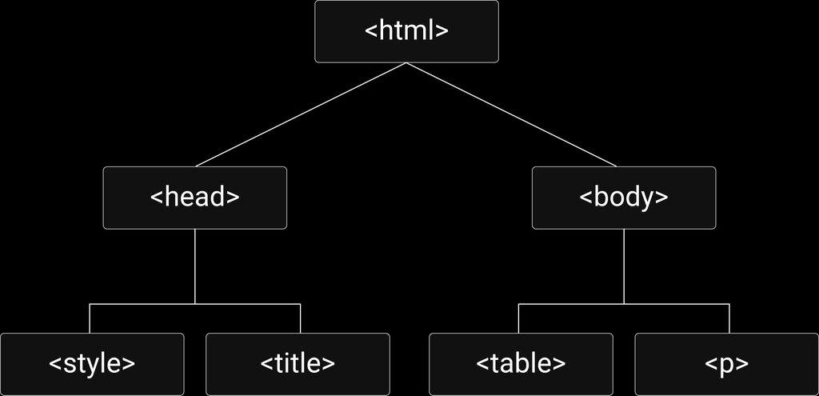

## Read a webpage into R

In this example, we look at [Wikipedia’s Economy of Switzerland page](https://en.wikipedia.org/wiki/Economy_of_Switzerland).

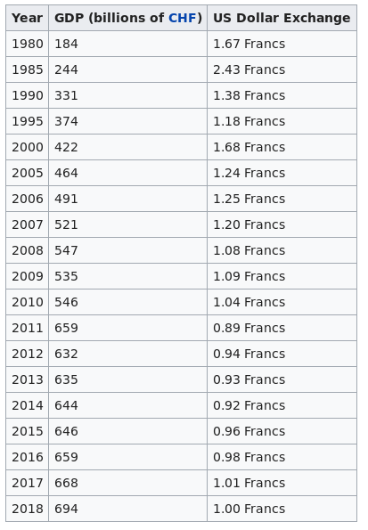

Source: https://en.wikipedia.org/wiki/Economy_of_Switzerland

## Tutorial (advanced): Importing data from a HTML table

-> Exercise session last week!

# Text as Data and Image Data

## Text as Data became more common as data source

- Extract text from historical documents (scan, use OCR)
- Use machine learning to label text (too costly to do manually)
- Extract sentiment (finance for instance)

#### Text is unstructured data. Text analysis and feature extraction is the basis for new genAI models!

## An example of text mining in R

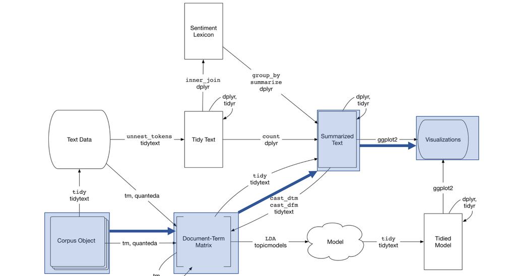

Source: https://confessionsofadatascientist.com/text-analysis-with-r-repro-report.html

## Self-study on text mining

**Read Chapter 6 on text data in [the book by U. Matter](https://umatter.github.io/datahandling/text-data.html)**

#### Key concepts:

- **regular expressions**: flexible syntax used to detect and describe patterns in strings
- **corpus**: a collection of authentic text organized into datasets
- **documents**
- **tokens** and **N-grams**
- **document-term-matrix** (dtm)

#### Key libraries:

- `quanteda`: see [Quanteda](https://quanteda.io/)
- `tidytext`: see [Text Mining with R](https://www.tidytextmining.com/)

# Exercises

## JSON files: open-ended question

Consider the following JSON file

```json
{
  "students": [
    {
      "id": 19091,
      "firstName": "Peter",
      "lastName": "Mueller",
      "grades": {
          "micro": 5,
          "macro": 4.5,
          "data handling": 5.5
          }
    },
    {
      "id": 19092,
      "firstName": "Anna",
      "lastName": "Schmid",
      "grades": {
          "micro": 5.25,
          "macro": 4,
          "data handling": 5.75
          }
    },
    {
      "id": 19093,
      "firstName": "Noah",
      "lastName": "Trevor",
      "grades": {
          "micro": 4,
          "macro": 4.5,
          "data handling": 5
          }
    }
  ]
}
```

Write an R code to extract a table with, as a first column, a vector of first names, and as a second column, the average grade per student. The table can be a data frame or a tibble.

## XML

```xml
<students>
  <student>
    <id>19091</id>
    <firstName>Peter</firstName>
    <lastName>Mueller</lastName>
    <grades>
      <micro>5</micro>
      <macro>4.5</macro>
      <dataHandling>5.5</dataHandling>
    </grades>
  </student>
  <student>
    <id>19092</id>
    <firstName>Anna</firstName>
    <lastName>Schmid</lastName>
    <grades>
      <micro>5.25</micro>
      <macro>4</macro>
      <dataHandling>5.75</dataHandling>
    </grades>
  </student>
  <student>
    <id>19093</id>
    <firstName>Noah</firstName>
    <lastName>Trevor</lastName>
    <grades>
      <micro>4</micro>
      <macro>4.5</macro>
      <dataHandling>5</dataHandling>
    </grades>
  </student>
</students>
```